# Introduction

This report is made using UCI ML Breast Cancer Wisconsin data provided by [scikit-learn](https://scikit-learn.org/stable/datasets/toy_dataset.html#breast-cancer-dataset). It consists of 569 observations and 30 numerical features describing characteristics of a breast mass, obtained using digitized image of a fine needle aspirate (FNA). These features are meant to be used for prediction of cancer malignancy, i.e. differentiate between benign and malignant tumors.

The goal of this report is assessing variable importance. Since chosen dataset is relatively small and easy to predict, probably the biggest concern should be overfitting. Obvious solution to this problem is cross validation. In this report analysis of variable importance is performed on different folds, i.e. following pipeline is made:

- no feature engineering or data preprocessing is performed,
- dataset is splitted into train/test with $\frac{2}{1}$ ratio,
- all 7 models are random forests with random_state=64 and max_depth=5,
- all 7 models have access to all available features,
- model's performance is meassured by f1-score and false positive rate, i.e. number of incorrectly classified malignant tumors,
- only difference between models is data seen during training, i.e. dataset is splitted using different random seed for each model,
- variable importance is assessed with `dalex` package.

## Reference model

Firstly, reference model is trained on data splitted with random state subjectively chosen as 64. It performs rather well both on training and testing data:

- train F1: 0.9958
- train FPR: 0.0141
- test F1: 0.9750
- test FPR: 0.0714

Most crucial variables are worst radius and worst area of the tumor, reflected by the most significant drop-out loss.

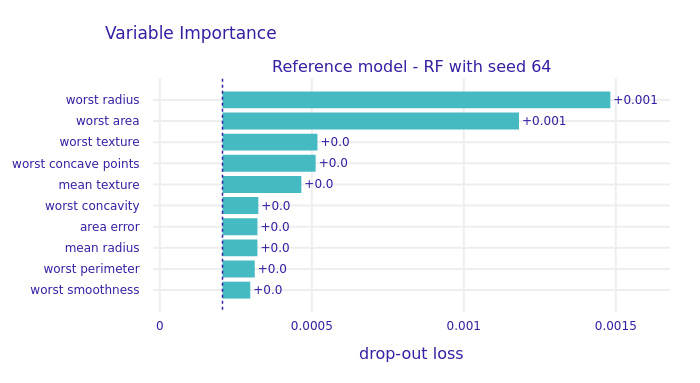

## Candidate models

For candidate models following random seeds are subjectively used: 128, 2, 16, 256, 512, 0.

Performance of candidate models is similar, however three of them are clearly overfitting:

- model trained on data spliited with seed=128; train F1: 1.0000 -> test F1: 0.9487,
- model trained on data spliited with seed=512; train F1: 0.9979 -> test F1: 0.9580,
- model trained on data spliited with seed=0; train F1: 1.0000 -> test F1: 0.9576.

## Model comparison

Due to overfitting, three models mentioned above are discarded and not used in final part of assessing variable importance. However, it is worth noticing that all of them are almost indifferent to variable permutations.

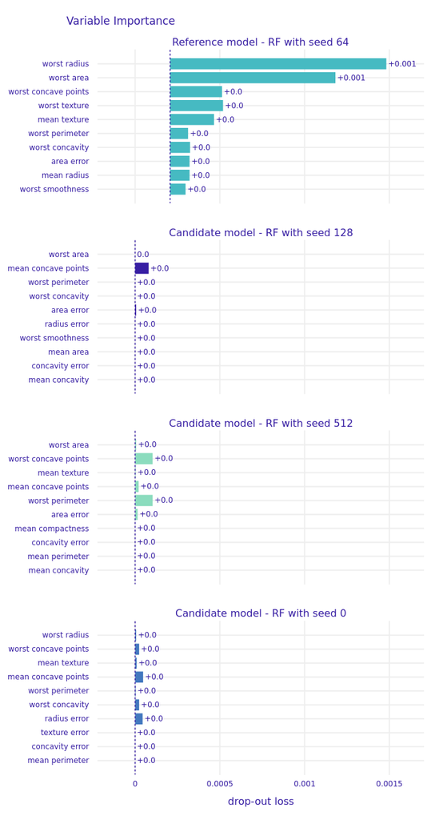

Despite different drop-out loss, six out of ten most important variables are exactly the same and in the exactly same order for other four models. These are:

- worst area,
- worst radius,
- worst concave points,
- worst texture,
- mean texture,
- worst perimeter.

It is worth noticing that these variables are describing different characteristics of a breast mass, i.e. models' predictions are made not only on one aspect of the tumor. This is a desirable behaviour of a model, or at least $\textit{expected}$ one. It is intuitively expected that final decision of a doctor is made considering many factors.

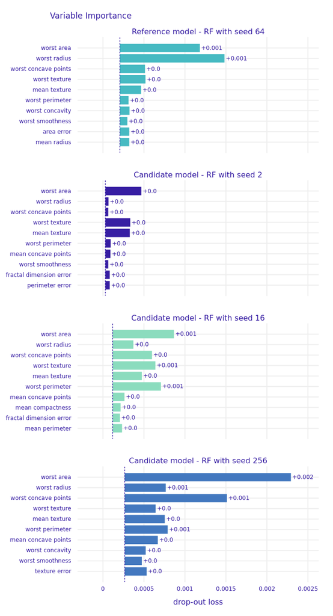